[figure not shown]

Curso de pregrado · 2026-2

# Análisis de Algoritmos

Diseño, análisis y comparación de algoritmos eficientes para resolver problemas computacionales con rigor y criterio.

🏛️ Pontificia Universidad Javeriana 💻 Departamento de Ingeniería de Sistemas 📚 Semestre 2026-2

[📘 Texto del curso: Levitin](https://www.dropbox.com/scl/fi/xqylznpmk83pm0xo6e9sw/Levitin3Ed.pdf?rlkey=soaeczl7hf9cbin9omq8h9g3p&dl=1) [🗂️ Exámenes y proyectos anteriores](https://www.dropbox.com/scl/fi/nwsgmps3n16wulw502d5g/ExamenesAnterioresDef.zip?rlkey=lk94w680jynys9v4gn1mmco3d&dl=1) [🗂️Código QR Luness](https://www.dropbox.com/scl/fi/v3sgn6g975gb8j601rexc/CodigoQrGrupoWappLunes.jpeg?rlkey=l1jg8axyd4f0cxgin82uvkl4s&dl=1) [🗂Código QR Martes](https://www.dropbox.com/scl/fi/x2nun185dlhrh7h5678ye/CodigoQrWappMartes.jpeg?rlkey=pdnnbg0k10i5nkm7gzlz6tmpd&dl=1) [📘Comic Book](https://www.dropbox.com/scl/fi/z3pbvynkeklhzhu9zsc16/Coleccion_Levitin_Completa_Capitulos_01_al_12.pdf?rlkey=etptqzfu4el878bkxdrk9ieey&dl=0) [📘Libro Interactivos](https://jamelende.github.io/PaginasWeb/Pregrado/Anal/Apps/Libro_Interactivo_Analisis_Algoritmos_Completo.html) [📘Puzzles Lab](https://jamelende.github.io/PaginasWeb/Pregrado/Anal/Apps/AlgPuzzlesTutorials.html)

# Pestañas

## Información General

[figure not shown]

### Propósito del curso

El curso de pregrado en Análisis de Algoritmos se centra en proporcionar a los estudiantes una comprensión profunda de la eficiencia y el rendimiento de los algoritmos utilizados en la resolución de problemas computacionales. A lo largo del curso, los estudiantes aprenderán a evaluar la complejidad temporal y espacial de los algoritmos, considerando aspectos prácticos como el tiempo de ejecución y el consumo de memoria. Se explorarán técnicas avanzadas de diseño y optimización de algoritmos, incluyendo estrategias de programación dinámica, algoritmos de búsqueda y clasificación, y técnicas de aproximación. Además, se abordarán conceptos fundamentales de teoría de grafos y estructuras de datos eficientes para proporcionar a los estudiantes las herramientas necesarias para desarrollar algoritmos eficaces y resolver problemas computacionales de manera efectiva.

El objetivo principal del curso es capacitar a los estudiantes para analizar críticamente algoritmos y tomar decisiones fundamentadas sobre la selección y aplicación de enfoques algorítmicos en diversos contextos. Se fomentará el pensamiento analítico y la habilidad para evaluar el rendimiento de un algoritmo en términos de eficiencia y escalabilidad. A través de ejercicios prácticos y proyectos, los estudiantes desarrollarán habilidades esenciales para diseñar algoritmos eficientes y comprenderán cómo estas habilidades son cruciales en la resolución de problemas en campos como inteligencia artificial, optimización y análisis de datos a gran escala.

### Objetivos

- Analizar la Complejidad Computacional: Explorar la teoría de la complejidad computacional para comprender la diferencia entre problemas de fácil resolución y aquellos que son intrínsecamente difíciles. Esto incluye el estudio de clases de complejidad, como P, NP y NP-completo.
- Aplicar Conceptos Teóricos en el Diseño de Algoritmos: Capacitar a los estudiantes para aplicar los conocimientos teóricos en el diseño y análisis de algoritmos eficientes, considerando restricciones de tiempo y espacio.
- Desarrollar Habilidades de Pensamiento Lógico y Analítico: Fomentar el desarrollo de habilidades de pensamiento lógico y analítico al abordar problemas computacionales desde una perspectiva teórica, preparando a los estudiantes para resolver desafíos algorítmicos complejos.

## Profesor

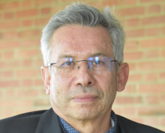

### M.Sc. Alfonso Meléndez

Profesor Titular · Escuela Colombiana de Ingeniería

[Ver hoja de vida](https://jamelende.github.io/PaginasWeb/HojadeVida/HojaDeVida2026.html)

## Periodo 1

[figure not shown]

[¡¡¡¡Nuevo!!!! Examenes y Proyectos Semesteres Anteriores](https://www.dropbox.com/scl/fi/nwsgmps3n16wulw502d5g/ExamenesAnterioresDef.zip?rlkey=lk94w680jynys9v4gn1mmco3d&dl=1)

[Texto del Curso Anany Levitin, The Design and analysis of Algorithms](https://www.dropbox.com/scl/fi/xqylznpmk83pm0xo6e9sw/Levitin3Ed.pdf?rlkey=soaeczl7hf9cbin9omq8h9g3p&dl=1)

[Video: Biggest Breakthroughs in Computer Science (Hashing)](https://www.youtube.com/watch?v=DFwppvrL_pE)

[output not shown]

## Periodo 2

|  | Descripción | Diapositivas | Lecturas y Talleres | Material Adicional |
| --- | --- | --- | --- | --- |
| **Semana 1** | **Examen Primer Periodo** | **Examen Primer Periodo** **Sustentación Examen Primer Periodo** | **Examen Primer Periodo** **Sustentación Examen Primer Periodo** | **Examen Primer Periodo** **Sustentación Examen Primer Periodo** |

## Periodo 3

|  | Descripción | Diapositivas | Lecturas y Talleres | Material Adicional |
| --- | --- | --- | --- | --- |
| **Semana 1** | **Examen Segundo Periodo** | **Examen Segundo Periodo** **Sustentación Examen Segundo Periodo** | **Examen Segundo Periodo** **Sustentación Examen Segundo Periodo** | **Examen Segundo Periodo** **Sustentación Examen Segundo Periodo** |

## Libros

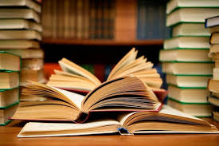

[1. Anany Levitin, Algorithmic Puzzles](https://www.dropbox.com/scl/fi/ohtvkvde4y1k8n2epfgsf/Algorithmic-Puzzles-Levitin-Anany-Levitin-Maria-2020-2011-Oxford-University-Press-9780199740444-ecf78b0903aebe9.pdf?rlkey=nm7yprg79jwzk2pqnpg2gr0wj&dl=1)  
2. Thomas Cormen, Int to Algorithms Fourth Edition 2022

[3. Learning Algorithms Through Problem Solving](https://www.dropbox.com/scl/fi/ncidspapr6u4gocqx6k3p/Learning-Algorithms-Through-Programming-and-Puzzle-Solving-PDFDrive.com-1.pdf?rlkey=2w7v91gbxd1orwytdvj39yruj&dl=1)  
[4. Grokking Algorithms](https://www.dropbox.com/scl/fi/qr6rkd9m9y8oaap4t8xzm/Grokking-Algorithms-Aditya-Y_-Bhargava.pdf?rlkey=dxdimi6iuinzoa68xsgwai66f&dl=1)

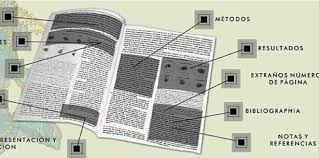

## Cursos en Línea

[figure not shown]

[A Second Course in Algorithms,Tim RoughGarden](https://www.youtube.com/watch?v=dorq_YA6plQ&list=PLEGCF-WLh2RJh2yDxlJJjnKswWdoO8gAc)  
[Approximation Algorithms Course](https://www.csa.iisc.ac.in/~arindamkhan/courses/ApproxAlgo22/ApproxAlgo.html)

## Videos

[figure not shown]

**Dancing Algorithms**

[Quicksort](https://www.youtube.com/watch?v=3San3uKKHgg&t=3s)  
[BubbleSort](https://www.youtube.com/watch?v=Iv3vgjM8Pv4&t=1s)  
[InsertionSort](https://www.youtube.com/watch?v=ROalU379l3U)  
[SelectionSort](https://www.youtube.com/watch?v=Ns4TPTC8whw)  
[All Algorithms](https://www.youtube.com/watch?v=INHF_5RIxTE)

**Master Theorem**

## Sitios Interactivos

[figure not shown]

[See Algorithms](https://see-algorithms.com)  
[Visualizador de Algoritmos](https://visualgo.net/en)  
[Algorithms Animations and Visualizations](https://algoanim.ide.sk/)  
[Sitio de David Galles, Muy Completo](https://www.cs.usfca.edu/~galles/visualization/Algorithms.html)  
[Algoritmos de Ordenamiento](https://www.toptal.com/developers/sorting-algorithms)  
[The sound of Sorting](https://panthema.net/2013/sound-of-sorting/) [Pedagogical Resources Gabriel Robbins](https://www.cs.virginia.edu/~robins/CS_readings.html)